# AACR GENIE Notes

Sep Dadsetan

1/17/2017

```r
knitr::opts_chunk$set(comment = NA)
library(ggplot2)
library(dplyr)
library(XML)
library(reshape2)
library(tidyr)
```

### Overview

There are two datasets in the AACR GENIE project that will be explored in this document. The GENIE data comes from [here] http://www.aacr.org/RESEARCH/RESEARCH/PAGES/AACR-PROJECT-GENIE-DATA.ASPX and was already downloaded into our Syapse Google Drive. 1. data_clinical.txt - Description: De-identified tier 1 clinical data. - Tab-delimited: rows represent samples, columns represent de-identified clinical attributes. 2. data_mutations_extended.txt - Description: Mutation data.

We will also create a third data set by scraping mycancergenome.org that will contain a list of therapies, their gene targets, and their approved indication.

### Clincal Data Transformation

##### Prepare the raw data set for easier analysis.

- Read in clinical data as a tab delimited file and don’t create factors.
- Convert column headers to lower case.
- Convert the “age_at_seq_report” to numeric, but coerce “”, “<18”, and “>89” to NAs. This amounts to 461 entries out of 18966 (~2.4%) being NA
- Convert “center”, “ethnicity”, “oncotree_code”, “primary_race”, “sample_type”, “seq_assay_id”, “sex”, “cancer_type”, “cancer_type_detailed” into factors
- Provide value labels to “center” so we don’t need to decipher their codes

```r
clinical <- read.delim("../data/data_clinical.txt", sep = "\t", stringsAsFactors = FALSE)
names(clinical) <- tolower(names(clinical))
clinical$age_at_seq_report <- as.numeric(clinical$age_at_seq_report)
clinical$center <- as.factor(clinical$center)
clinical$ethnicity <- as.factor(clinical$ethnicity)
clinical$oncotree_code <- as.factor(clinical$oncotree_code)
clinical$primary_race <- as.factor(clinical$primary_race)
clinical$sample_type <- as.factor(clinical$sample_type)
clinical$seq_assay_id <- as.factor(clinical$seq_assay_id)
clinical$sex <- as.factor(clinical$sex)
clinical$cancer_type <- as.factor(clinical$cancer_type)
clinical$cancer_type_detailed <- as.factor(clinical$cancer_type_detailed)

center_labels <- c("Dana Farber Cancer Institute", "Institut Gustave Roussy", "Johns Hopkins Sidney Kimmel Comprehensive Cancer Center", "MD Anderson Cancer Center", "Memorial Sloan Kettering Cancer Center", "Netherlands Cancer Institute", "Princess Margaret Cancer Centre", "Vanderbilt-Ingram Cancer Center")
clinical$center <- factor(clinical$center, levels = levels(clinical$center), labels = center_labels)
```

### Mutation Data Transformation

The original “data_mutations_extended.txt”" file has a list of all the GENIE sample id’s in one line at the top of the file. We don’t need these as they are already part of the table in “tumor_sample_barcode”. So let’s begin the import on the necessary line. Note: there are multiple observations per sample.

All participating institution’s contributions were processed by a pipeline to unify the results under a common set of variables. Below is a description from the data_guide.pdf.

Contributing GENIE centers provided mutation data in Variant Call Format (VCF v4.x, samtools.github.io/hts-specs ) or Mutation Annotation Format (MAF v2.x, wiki.nci.nih.gov/x/eJaPAQ ) with additional fields for read counts supporting variant alleles, reference alleles, and total depth. Some “MAF-like” text files with minimal required columns ( github.com/mskcc/vcf2maf/blob/v1.6.12/data/minimalist_test_maf.tsv ) were also received from the participating centers. These various input formats were converted into a complete tab-separated MAF v2.4 format, with a standardized set of additional columns ( github.com/mskcc/vcf2maf/blob/v1.6.12/docs/vep_maf_readme.txt) usingeithervcf2mafor maf2maf v1.6.12 ( github.com/mskcc/vcf2maf/tree/v1.6.12 ), wrappers around the Variant Effect Predictor (VEP v86, gist.github.com/ckandoth/f265ea7c59a880e28b1e533a6e935697) . The vcf2maf “custom-enst” option overrode VEP’s canonical isoform for most genes, with Uniprot’s canonical isoform ( github.com/mskcc/vcf2maf/blob/v1.6.12/data/isoform_overrides_uniprot ).

For detailed information regarding all variables in the mutation data set, visit the MAF specification and the [vcf2maf readme from MSK](https://github.com/mskcc/vcf2maf/blob/master/docs/vep_maf_readme.txt).

For our interests, we’re going to filter the variables that will enable us to answer our questions and include the advice layed out in the vep_maf_readme.txt on line 109 about helping distinguish driver mutations.

```r
mutation <- read.delim("../data/data_mutations_extended.txt", sep = "\t", skip = 1, stringsAsFactors = FALSE)
names(mutation) <- tolower(names(mutation))

# Convert variables to proper types
mutation$hugo_symbol <- as.factor(mutation$hugo_symbol)
mutation$center <- as.factor(mutation$center)
mutation$chromosome <- as.factor(mutation$chromosome)
mutation$variant_classification <- as.factor(mutation$variant_classification)
mutation$variant_type <- as.factor(mutation$variant_type)
mutation$validation_status <- as.factor(mutation$validation_status)
mutation$mutation_status <- as.factor(mutation$mutation_status)

# Let's create a new data.frame with a smaller set of variables
keep_columns <- c("hugo_symbol", "entrez_gene_id", "center", "chromosome", "variant_classification", "variant_type", "dbsnp_rs", "tumor_sample_barcode", "consequence", "impact", "clin_sig")
mutation_2 <- mutation[, keep_columns]

# Place NA in blank cells to make analysis a bit eaasier
mutation_2[mutation_2 == ""] <- NA
```

### Scrape Therapy Table from mycancergenome.org

We’re going to be grabbing the table from this [url](http://www.mycancergenome.org/content/molecular-medicine/overview-of-targeted-therapies-for-cancer/) and making it into a data.frame that we can manipulate and use as cross-reference for the clinical and mutation data.

Since mycancergenome.org seems to prevent RCurl from getting the page source, I just grabbed the table html and made a file in **data/therapies.html** to make available for readHTMLTable.

```r
# read in html
therapies <- readHTMLTable("../data/therapies.html", stringsAsFactors = FALSE)

# Convert it to a data.frame since it's a list, name the variables, and remove remnant of table header first line
therapies <- as.data.frame(therapies)
names(therapies) <- c("agent", "target", "approved_indication")
therapies <- therapies[-1,]

# Now need to mutate and clean up data.frame
# Each row should be a single target with a single agent and approved indication.
# First we'll tackle the 'target' column by splitting on ',' and unnest (tidyr)
therapies <- therapies %>%
    mutate(target = strsplit(as.character(target), ",")) %>%
    unnest(target)

# Next we'll tackle the "approved_indication" column and split out the values delimited by a carriage return
therapies <- therapies %>%
    mutate(approved_indication = strsplit(as.character(approved_indication), "\n")) %>%
    unnest(approved_indication)

# Clean up the greek characters in targets and approved therapies and remove leading/trailing whitespace
therapies$target <- replace(therapies$target, therapies$target == "IL-1Î²", "IL-1-Beta")
therapies$target <- replace(therapies$target, therapies$target == "PI3KÎ´", "PI3K-Delta")
therapies$target <- replace(therapies$target, therapies$target == "PDGFRÎ±", "PDGFR-Alpha")
therapies$target <- replace(therapies$target, therapies$target == " PDGFRÎ²", "PDGFR-Beta")
therapies$approved_indication <- replace(therapies$approved_indication, therapies$approved_indication == "Non-Hodgkinâ\u0080\u0099s lymphoma", "Non-Hodgkin's lymphoma")
therapies$approved_indication <- replace(therapies$approved_indication, therapies$approved_indication == "â\u0080\u008bMyelofibrosis", "Myelofibrosis")


trim <- function (x) gsub("^\\s+|\\s+$", "", x)
therapies$target <- trim(therapies$target)
therapies$approved_indication <- trim(therapies$approved_indication)

# Need to unify the 'approved_indication' variable to match OncoTree used in the mutation/clinical data

# Output the data.table for safe keeping
write.csv(therapies, "../data/therapies_tidy.csv")
```

### Clinical Data Summary

```r
# What's the structure of clinical data?
str(clinical)
```

```
'data.frame':   18966 obs. of  12 variables:
 $ age_at_seq_report   : num  53 67 59 64 64 53 79 82 65 43 ...
 $ center              : Factor w/ 8 levels "Dana Farber Cancer Institute",..: 1 1 1 1 1 1 1 1 1 1 ...
 $ ethnicity           : Factor w/ 3 levels "Non-Spanish/non-Hispanic",..: 1 3 1 1 1 1 3 1 1 1 ...
 $ oncotree_code       : Factor w/ 478 levels "AASTR","ACA",..: 208 56 419 208 208 357 48 208 215 419 ...
 $ patient_id          : chr  "GENIE-DFCI-001930" "GENIE-DFCI-001235" "GENIE-DFCI-001296" "GENIE-DFCI-000145" ...
 $ primary_race        : Factor w/ 6 levels "Asian","Black",..: 6 6 6 6 6 6 6 5 6 6 ...
 $ sample_id           : chr  "GENIE-DFCI-001930-3071" "GENIE-DFCI-001235-3925" "GENIE-DFCI-001296-2850" "GENIE-DFCI-000145-3971" ...
 $ sample_type         : Factor w/ 3 levels "Metastasis","Primary",..: 2 1 2 1 1 2 2 1 2 2 ...
 $ seq_assay_id        : Factor w/ 12 levels "DFCI-ONCOPANEL-1",..: 1 2 1 2 2 1 2 2 2 2 ...
 $ sex                 : Factor w/ 2 levels "Female","Male": 1 1 1 2 2 1 1 1 1 1 ...
 $ cancer_type         : Factor w/ 59 levels "Adenocarcinoma In Situ",..: 39 8 56 39 39 40 6 39 39 56 ...
 $ cancer_type_detailed: Factor w/ 467 levels "Acinar Cell Carcinoma of the Pancreas",..: 208 192 299 208 208 369 47 208 212 299 ...
```

```r
# What are the summary statistics around the age of the patients?
summary(clinical$age_at_seq_report)
```

```
   Min. 1st Qu.  Median    Mean 3rd Qu.    Max.    NA's
  18.00   50.00   60.00   58.58   68.00   89.00     461
```

```r
# What 'center' contributes the most/the least?
as.data.frame(sort(table(clinical$center), decreasing = TRUE))
```

```
                                                     Var1 Freq
1                  Memorial Sloan Kettering Cancer Center 7341
2                            Dana Farber Cancer Institute 6299
3                         Princess Margaret Cancer Centre 1296
4 Johns Hopkins Sidney Kimmel Comprehensive Cancer Center 1203
5                               MD Anderson Cancer Center  961
6                         Vanderbilt-Ingram Cancer Center  832
7                                 Institut Gustave Roussy  529
8                            Netherlands Cancer Institute  505
```

```r
# What race is most represented in the data set?
as.data.frame(sort(table(clinical$primary_race), decreasing = TRUE))
```

```
             Var1  Freq
1           White 14914
2         Unknown  1892
3           Black   948
4           Asian   841
5           Other   355
6 Native American    16
```

```r
# What is the gender distribution?
as.data.frame(sort(table(clinical$sex), decreasing = TRUE))
```

```
    Var1  Freq
1 Female 10307
2   Male  8659
```

```r
# What are the top ten cancer types classified in this data set?
as.data.frame(sort(table(clinical$cancer_type), decreasing = TRUE)[1:10])
```

```
                         Var1 Freq
1  Non-Small Cell Lung Cancer 3006
2               Breast Cancer 2230
3           Colorectal Cancer 2102
4                      Glioma  977
5              Ovarian Cancer  945
6                    Melanoma  785
7             Prostate Cancer  753
8              Bladder Cancer  641
9         Soft Tissue Sarcoma  635
10         Endometrial Cancer  558
```

```r
# What are the top ten detailed cancer types?
as.data.frame(sort(table(clinical$cancer_type_detailed), decreasing = TRUE)[1:10])
```

```
                               Var1 Freq
1               Lung Adenocarcinoma 2383
2  Breast Invasive Ductal Carcinoma 1505
3              Colon Adenocarcinoma 1034
4           Prostate Adenocarcinoma  734
5         Colorectal Adenocarcinoma  690
6      Bladder Urothelial Carcinoma  481
7  High-Grade Serous Ovarian Cancer  479
8           Glioblastoma Multiforme  448
9                Cutaneous Melanoma  368
10        Pancreatic Adenocarcinoma  348
```

### Mutation Data Summary

```r
# What are the top ten genes identified in GENIE?
as.data.frame(sort(table(mutation_2$hugo_symbol), decreasing = TRUE)[1:10])
```

```
     Var1 Freq
1    TP53 8140
2    KRAS 2858
3  PIK3CA 2710
4     APC 2682
5   KMT2D 1977
6  ARID1A 1492
7    PTEN 1315
8    EGFR 1216
9     ATM 1208
10   BRAF 1124
```

```r
# Does the sequencing output match the the number of patients per center?
as.data.frame(sort(table(mutation_2$center), decreasing = TRUE))
```

```
  Var1  Freq
1  MSK 48974
2 DFCI 47498
3 VICC  7653
4  JHU  2348
5  UHN  2097
6  MDA  1242
7  NKI   857
8 GRCC   807
```

```r
# What chromosomes appear the most?
as.data.frame(sort(table(mutation_2$chromosome), decreasing = TRUE))
```

```
   Var1  Freq
1    17 13854
2     3  9403
3    12  8718
4     1  7352
5     7  6442
6     5  6400
7     2  5876
8    19  5504
9     X  5379
10    9  5192
11    4  4872
12   16  4719
13    6  4507
14   11  4130
15   13  3787
16   10  3472
17    8  2523
18   20  2289
19   15  2020
20   22  1716
21   18  1602
22   14  1192
23   21   527
```

```r
# What variant class is most frequent?
as.data.frame(sort(table(mutation_2$variant_classification), decreasing = TRUE))
```

```
                     Var1  Freq
1       Missense_Mutation 83723
2       Nonsense_Mutation 10492
3         Frame_Shift_Del  7332
4         Frame_Shift_Ins  3052
5             Splice_Site  2621
6            In_Frame_Del  1915
7            In_Frame_Ins   699
8                  Intron   561
9                  Silent   458
10                5'Flank   168
11 Translation_Start_Site   141
12          Splice_Region    89
13                  3'UTR    63
14                  5'UTR    56
15                3'Flank    55
16       Nonstop_Mutation    51
```

```r
# What variant types are most frequent?
as.data.frame(sort(table(mutation_2$variant_type), decreasing = TRUE))
```

```
  Var1  Freq
1  SNP 96388
2  DEL  9848
3  INS  3966
4  DNP  1142
5  TNP    81
6  ONP    51
```

### Therapy Data Summary

```r
# What targets have the most therapies?
as.data.frame(sort(table(therapies$target), decreasing = TRUE))
```

```
                       Var1 Freq
1                       KIT   12
2         EGFR (HER1/ERBB1)   10
3                    VEGFR2   10
4                       ABL    9
5                      CD20    9
6                      PD-1    8
7               VEGF ligand    8
8                     PDGFR    7
9          HER2 (ERBB2/neu)    6
10                     HDAC    5
11                     mTOR    5
12                      RAF    5
13                      RET    5
14                     FLT3    4
```

[output cut: 36 more lines]

```r
# What indications have most therapies? *The values haven't been unified, so indications may not be counted accurately
as.data.frame(sort(table(therapies$approved_indication), decreasing = TRUE))
```

```
                                                                                                 Var1
1                                                                                Renal cell carcinoma
2                                                                                   Colorectal cancer
3                                                                            Medullary thyroid cancer
4                                     Acute lymphoblastic leukemia (Philadelphia chromosome positive)
5                                                                               Breast cancer (HER2+)
6                                                                        Chronic lymphocytic leukemia
7                                                                     Gastrointestinal stromal tumors
8                                                                                    Multiple myeloma
9                                                                        Chronic myelogenous leukemia
10                                                                           Hepatocellular carcinoma
11                                                                         Non-small cell lung cancer
12 Non-small cell lung cancer (with EGFR exon 19 deletions or exon 21 substitution (L858R) mutations)
13                                                                                  Thyroid carcinoma
14                                                                               Basal cell carcinoma
```

[output cut: 123 more lines]

### Create joined table to examine gene/indication relationship

In order to look at gene prevalence by cancer type, we need to join our mutation_2 and clinical tables. This will yield a lot of rows with duplicated information from the clinical table, but we’re specifically interested in hugo_gene and cancer_type.

```r
# Join the tables based on tumor_sample_barcode and sample_id
mutation_clinical_join <- left_join(mutation_2, clinical, by = c("tumor_sample_barcode" = "sample_id"))

# Filter only mutations that have clinical significance according to ClinVar ("clin_sig") property
clin_sig_mutations_only <- mutation_clinical_join[!is.na(mutation_clinical_join$clin_sig),]
# Of those, let's only look at clin_sig of "pathogenic" or "likely_pathogenic"
pathogenic_clin_sig_mutations_only <- dplyr::filter(clin_sig_mutations_only, grepl("pathogenic", clin_sig))

# What percent of mutations reported are "pathogenic" or "likely pathogenic"?
nrow(pathogenic_clin_sig_mutations_only) / nrow(mutation_clinical_join)
```

```
[1] 0.1233539
```

```r
# What percent of clinically significant mutations are "pathogenic" or "likely pathogenic"?
nrow(pathogenic_clin_sig_mutations_only) / nrow(clin_sig_mutations_only)
```

```
[1] 0.7563806
```

```r
# Let's take the most restricted number of mutations (those marked "pathogenic") and get a table of gene counts per cancer type and rename variables
gene_count_per_indication <- as.data.frame(table(pathogenic_clin_sig_mutations_only$hugo_symbol, pathogenic_clin_sig_mutations_only$cancer_type))
names(gene_count_per_indication) <- c("target", "cancer_type", "counts")

# Filter out the counts that are zero
gene_count_per_indication <- dplyr::filter(gene_count_per_indication, counts != 0)

# Arrange the data table so the most frequent gene counts appear at the top
gene_count_per_indication <- arrange(gene_count_per_indication, desc(counts))

# What are the top ten most frequent genes to be implicated with "pathogenic" mutations?
as.data.frame(sort(table(gene_count_per_indication$target), decreasing = TRUE)[1:10])
```

```
     Var1 Freq
1    TP53   44
2  PIK3CA   39
3    KRAS   38
4    BRAF   34
5    PTEN   32
6    NRAS   30
7     RB1   26
8  CTNNB1   24
9   BRCA2   23
10   GNAS   23
```

```r
# Of the list of therapeutic targets we've created from mycancergenome.org, how many of those targets can be found in the samples that were sequenced with mutations labeled as "pathogenic"?
sum(therapies$target %in% gene_count_per_indication$target) / length(therapies$target)
```

```
[1] 0.2121212
```

```r
# Give me only the therapies where the target gene is present in the mutation data. Note: these are still mutations that are considered to be "pathogenic" or "likely pathogenic". There are only about 35 therapies in our list that apply and those only target 10 genes.
# "ALK"  "KIT"  "FLT3" "MET"  "RET"  "BRAF" "BTK"  "EGFR" "CDK4" "JAK3"
selected_rows <- therapies$target %in% gene_count_per_indication$target
applicable_therapies_to_path_mutations <- therapies[selected_rows,]

# Of the therapies that have a specific target and approved indication, what percent of our GENIE patients (that have a "pathogenic" mutation in the target gene) also have the cancer type to which the therapy is approved?
# There's gotta be a way to do this more eloquently, but I'll resort to breaking it into smaller pieces
# Here are the list of therapy target genes that apply to our mutation data
# "ALK"  "KIT"  "FLT3" "MET"  "RET"  "BRAF" "BTK"  "EGFR" "CDK4" "JAK3"
# Let's go one by one and calculate the overlap of cancer type/approved indication

#### ALK
# Filter out all sequences that had the ALK gene
alk_mutations <- dplyr::filter(gene_count_per_indication, target == "ALK")
# Filter all therapies that target ALK and look at their approved_therapy
alk_therapies <- dplyr::filter(applicable_therapies_to_path_mutations, target == "ALK")
# Take a look at the approved indications for the therapies. Hint: They're all NSCLC
alk_therapies
```

```
                 agent target
1 Alectinib (Alecensa)    ALK
2  Ceritinib (Zykadia)    ALK
3 Crizotinib (Xalkori)    ALK
                                                   approved_indication
1                         Non-small cell lung cancer (with ALK fusion)
2                         Non-small cell lung cancer (with ALK fusion)
3 Non-small cell lung cancer (with ALK fusion or ROS1 gene alteration)
```

```r
# Take a look at the cancer types for individuals with pathogenic ALK mutation
alk_mutations
```

```
  target                           cancer_type counts
1    ALK                       Embryonal Tumor      6
2    ALK                     Colorectal Cancer      2
3    ALK Gastrointestinal Neuroendocrine Tumor      1
4    ALK            Non-Small Cell Lung Cancer      1
5    ALK                       Prostate Cancer      1
```

```r
# Only 1 patient has a cancer type of NSCLC which matches the approved indication. There are 11 patients total.
# What percentage of cancer types with ALK occurances in the GENIE mutation list ARE in the approved_indication of ALK targeted therapies?
sum(alk_mutations[alk_mutations$cancer_type == "Non-Small Cell Lung Cancer",]$count) / sum(alk_mutations$count)
```

```
[1] 0.09090909
```

```r
# What percentage of cancer types with ALK occurances in the GENIE mutation list ARE NOT the approved_indication of ALK targeted therapies?
sum(alk_mutations[alk_mutations$cancer_type != "Non-Small Cell Lung Cancer",]$count) / sum(alk_mutations$count)
```

```
[1] 0.9090909
```

```r
#### KIT
# Filter out all sequences that had the KIT gene
kit_mutations <- dplyr::filter(gene_count_per_indication, target == "KIT")
# Filter all therapies that target KIT and look at their approved_therapy
kit_therapies <- dplyr::filter(applicable_therapies_to_path_mutations, target == "KIT")
# Take a look at the approved indications for the therapies.
unique(kit_therapies$approved_indication)
```

```
[1] "Renal cell carcinoma"
[2] "Medullary thyroid cancer"
[3] "GI stromal tumor (KIT+)"
[4] "Dermatofibrosarcoma protuberans"
[5] "Multiple hematologic malignancies including Philadelphia chromosome-positive ALL and CML"
[6] "Colorectal cancer"
[7] "Gastrointestinal stromal tumors"
[8] "Hepatocellular carcinoma"
[9] "Thyroid carcinoma"
```

```r
# Take a look at the cancer types for individuals with pathogenic KIT mutation
kit_mutations
```

```
  target                    cancer_type counts
1    KIT Gastrointestinal Stromal Tumor     23
2    KIT                Germ Cell Tumor     12
3    KIT                       Melanoma     11
4    KIT         Adenocarcinoma In Situ      2
5    KIT                  Breast Cancer      1
6    KIT           Head and Neck Cancer      1
7    KIT                       Leukemia      1
8    KIT                 Myelodysplasia      1
```

```r
# What percentage of cancer types with KIT occurances in the GENIE mutation list ARE in the approved_indication of KIT targeted therapies?
# Only "Gastrointestinal Stromal Tumor" applies to our GENIE data.
sum(kit_mutations[kit_mutations$cancer_type == "Gastrointestinal Stromal Tumor",]$count) / sum(kit_mutations$count)
```

```
[1] 0.4423077
```

```r
# What percentage of cancer types with KIT occurances in the GENIE mutation list ARE NOT the approved_indication of KIT targeted therapies?
sum(kit_mutations[kit_mutations$cancer_type != "Gastrointestinal Stromal Tumor",]$count) / sum(kit_mutations$count)
```

```
[1] 0.5576923
```

```r
#### "FLT3"
# Filter out all sequences that had the FLT3 gene
flt3_mutations <- dplyr::filter(gene_count_per_indication, target == "FLT3")
# Filter all therapies that target FLT3 and look at their approved_therapy
flt3_therapies <- dplyr::filter(applicable_therapies_to_path_mutations, target == "FLT3")
# Take a look at the approved indications for the therapies.
unique(flt3_therapies$approved_indication)
```

```
[1] "Medullary thyroid cancer"
[2] "Renal cell carcinoma"
[3] "Chronic myelogenous leukemia"
[4] "Acute lymphoblastic leukemia (Philadelphia chromosome positive)"
```

```r
# Take a look at the cancer types for individuals with pathogenic FLT3 mutation
flt3_mutations
```

```
  target    cancer_type counts
1   FLT3       Leukemia      8
2   FLT3 Myelodysplasia      1
```

```r
# What percentage of cancer types with FLT3 occurances in the GENIE mutation list ARE in the approved_indication of FLT3 targeted therapies?
sum(flt3_mutations[flt3_mutations$cancer_type == "Leukemia",]$count) / sum(flt3_mutations$count)
```

```
[1] 0.8888889
```

```r
# What percentage of cancer types with FLT3 occurances in the GENIE mutation list ARE NOT the approved_indication of FLT3 targeted therapies?
sum(flt3_mutations[flt3_mutations$cancer_type != "Leukemia",]$count) / sum(flt3_mutations$count)
```

```
[1] 0.1111111
```

```r
####  "MET"
# Filter out all sequences that had the MET gene
met_mutations <- dplyr::filter(gene_count_per_indication, target == "MET")
# Filter all therapies that target MET and look at their approved_therapy
met_therapies <- dplyr::filter(applicable_therapies_to_path_mutations, target == "MET")
# Take a look at the approved indications for the therapies.
unique(met_therapies$approved_indication)
```

```
[1] "Medullary thyroid cancer"
[2] "Renal cell carcinoma"
[3] "Non-small cell lung cancer (with ALK fusion or ROS1 gene alteration)"
```

```r
# Take a look at the cancer types for individuals with pathogenic MET mutation
met_mutations
```

```
  target                cancer_type counts
1    MET       Renal Cell Carcinoma      3
2    MET Non-Small Cell Lung Cancer      2
3    MET             Ovarian Cancer      2
```

```r
# What percentage of cancer types with MET occurances in the GENIE mutation list ARE in the approved_indication of MET targeted therapies?
sum(met_mutations[met_mutations$cancer_type == "Renal Cell Carcinoma" | met_mutations$cancer_type == "Non-Small Cell Lung Cancer",]$count) / sum(met_mutations$count)
```

```
[1] 0.7142857
```

```r
# What percentage of cancer types with MET occurances in the GENIE mutation list ARE NOT the approved_indication of MET targeted therapies?
sum(met_mutations[met_mutations$cancer_type != "Renal Cell Carcinoma" & met_mutations$cancer_type != "Non-Small Cell Lung Cancer",]$count) / sum(met_mutations$count)
```

```
[1] 0.2857143
```

```r
####  "RET"
# Filter out all sequences that had the RET gene
ret_mutations <- dplyr::filter(gene_count_per_indication, target == "RET")
# Filter all therapies that target RET and look at their approved_therapy
ret_therapies <- dplyr::filter(applicable_therapies_to_path_mutations, target == "RET")
# Take a look at the approved indications for the therapies.
unique(ret_therapies$approved_indication)
```

```
[1] "Medullary thyroid cancer"        "Renal cell carcinoma"
[3] "Colorectal cancer"               "Gastrointestinal stromal tumors"
```

```r
# Take a look at the cancer types for individuals with pathogenic RET mutation
ret_mutations
```

```
  target          cancer_type counts
1    RET       Thyroid Cancer     21
2    RET        Breast Cancer      3
3    RET             Melanoma      2
4    RET       Bladder Cancer      1
5    RET    Colorectal Cancer      1
6    RET Head and Neck Cancer      1
7    RET             Leukemia      1
8    RET    Pancreatic Cancer      1
9    RET     Pheochromocytoma      1
```

```r
# What percentage of cancer types with RET occurances in the GENIE mutation list ARE in the approved_indication of RET targeted therapies?
sum(ret_mutations[ret_mutations$cancer_type == "Thyroid Cancer" | ret_mutations$cancer_type == "Colorectal Cancer",]$count) / sum(ret_mutations$count)
```

```
[1] 0.6875
```

```r
# What percentage of cancer types with RET occurances in the GENIE mutation list ARE NOT the approved_indication of RET targeted therapies?
sum(ret_mutations[ret_mutations$cancer_type != "Thyroid Cancer" & ret_mutations$cancer_type != "Colorectal Cancer",]$count) / sum(ret_mutations$count)
```

```
[1] 0.3125
```

```r
####  "BRAF"
# Filter out all sequences that had the BRAF gene
braf_mutations <- dplyr::filter(gene_count_per_indication, target == "BRAF")
# Filter all therapies that target BRAF and look at their approved_therapy
braf_therapies <- dplyr::filter(applicable_therapies_to_path_mutations, target == "BRAF")
# Take a look at the approved indications for the therapies.
unique(braf_therapies$approved_indication)
```

```
[1] "Melanoma (with BRAF V600 mutation)"
```

```r
# Take a look at the cancer types for individuals with pathogenic BRAF mutation
braf_mutations
```

```
   target                           cancer_type counts
1    BRAF                              Melanoma    239
2    BRAF                     Colorectal Cancer    211
3    BRAF                        Thyroid Cancer    154
4    BRAF            Non-Small Cell Lung Cancer    116
5    BRAF                                Glioma     22
6    BRAF                        Ovarian Cancer     17
7    BRAF             Cancer of Unknown Primary     12
8    BRAF                              Leukemia     12
9    BRAF                    Endometrial Cancer     11
10   BRAF                        Bladder Cancer     10
11   BRAF Gastrointestinal Neuroendocrine Tumor      9
12   BRAF                       Prostate Cancer      9
13   BRAF                  Hepatobiliary Cancer      8
14   BRAF                     Pancreatic Cancer      7
```

[output cut: 20 more lines]

```r
# What percentage of cancer types with BRAF occurances in the GENIE mutation list ARE in the approved_indication of BRAF targeted therapies?
sum(braf_mutations[braf_mutations$cancer_type == "Melanoma",]$count) / sum(braf_mutations$count)
```

```
[1] 0.2691441
```

```r
# What percentage of cancer types with BRAF occurances in the GENIE mutation list ARE NOT the approved_indication of BRAF targeted therapies?
sum(braf_mutations[braf_mutations$cancer_type != "Melanoma",]$count) / sum(braf_mutations$count)
```

```
[1] 0.7308559
```

```r
####  "BTK"
# Filter out all sequences that had the BTK gene
btk_mutations <- dplyr::filter(gene_count_per_indication, target == "BTK")
# Filter all therapies that target BTK and look at their approved_therapy
btk_therapies <- dplyr::filter(applicable_therapies_to_path_mutations, target == "BTK")
# Take a look at the approved indications for the therapies.
unique(btk_therapies$approved_indication)
```

```
[1] "Mantle cell lymphoma"            "Chronic lymphocytic leukemia"
[3] "Waldenstrom's macroglobulinemia"
```

```r
# Take a look at the cancer types for individuals with pathogenic BRAF mutation
btk_mutations
```

```
  target       cancer_type counts
1    BTK    Bladder Cancer      1
2    BTK Colorectal Cancer      1
3    BTK     Penile Cancer      1
```

```r
# What percentage of cancer types with BTK occurances in the GENIE mutation list ARE in the approved_indication of BTK targeted therapies?
0 / sum(btk_mutations$count)
```

```
[1] 0
```

```r
# What percentage of cancer types with BTK occurances in the GENIE mutation list ARE NOT the approved_indication of BTK targeted therapies?
sum(btk_mutations$count)
```

```
[1] 3
```

```r
####  "EGFR"
# Filter out all sequences that had the EGFR gene
egfr_mutations <- dplyr::filter(gene_count_per_indication, target == "EGFR")
# Filter all therapies that target EGFR and look at their approved_therapy
egfr_therapies <- dplyr::filter(applicable_therapies_to_path_mutations, target == "EGFR")
# Take a look at the approved indications for the therapies.
unique(egfr_therapies$approved_indication)
```

```
[1] "Non-small cell lung cancer (with EGFR T790M mutation)"
```

```r
# Take a look at the cancer types for individuals with pathogenic EGFR mutation
egfr_mutations
```

```
  target                cancer_type counts
1   EGFR Non-Small Cell Lung Cancer    163
2   EGFR                     Glioma      6
3   EGFR             Bladder Cancer      4
4   EGFR              Breast Cancer      1
```

```r
# What percentage of cancer types with EGFR occurances in the GENIE mutation list ARE in the approved_indication of EGFR targeted therapies?
sum(egfr_mutations[egfr_mutations$cancer_type == "Non-Small Cell Lung Cancer",]$count) / sum(egfr_mutations$count)
```

```
[1] 0.9367816
```

```r
# What percentage of cancer types with EGFR occurances in the GENIE mutation list ARE NOT the approved_indication of EGFR targeted therapies?
sum(egfr_mutations[egfr_mutations$cancer_type != "Non-Small Cell Lung Cancer",]$count) / sum(egfr_mutations$count)
```

```
[1] 0.06321839
```

```r
####  "CDK4"
# Filter out all sequences that had the CDK4 gene
cdk4_mutations <- dplyr::filter(gene_count_per_indication, target == "CDK4")
# Filter all therapies that target CDK4 and look at their approved_therapy
cdk4_therapies <- dplyr::filter(applicable_therapies_to_path_mutations, target == "CDK4")
# Take a look at the approved indications for the therapies.
unique(cdk4_therapies$approved_indication)
```

```
[1] "Breast cancer (ER+, HER2-)"
```

```r
# Take a look at the cancer types for individuals with pathogenic CDK4 mutation
cdk4_mutations
```

```
  target    cancer_type counts
1   CDK4       Melanoma      3
2   CDK4 Ovarian Cancer      1
```

```r
# What percentage of cancer types with CDK4 occurances in the GENIE mutation list ARE in the approved_indication of CDK4 targeted therapies?
0 / sum(cdk4_mutations$count)
```

```
[1] 0
```

```r
# What percentage of cancer types with CDK4 occurances in the GENIE mutation list ARE NOT the approved_indication of CDK4 targeted therapies?
sum(cdk4_mutations$count)
```

```
[1] 4
```

```r
####  "JAK3"
# Filter out all sequences that had the JAK3 gene
jak3_mutations <- dplyr::filter(gene_count_per_indication, target == "JAK3")
# Filter all therapies that target JAK3 and look at their approved_therapy
jak3_therapies <- dplyr::filter(applicable_therapies_to_path_mutations, target == "JAK3")
# Take a look at the approved indications for the therapies.
unique(jak3_therapies$approved_indication)
```

```
[1] "Rheumatoid arthritis"
```

```r
# Take a look at the cancer types for individuals with pathogenic JAK3 mutation
jak3_mutations
```

```
  target                cancer_type counts
1   JAK3       Non-Hodgkin Lymphoma      1
2   JAK3 Non-Small Cell Lung Cancer      1
```

```r
# What percentage of cancer types with JAK3 occurances in the GENIE mutation list ARE in the approved_indication of JAK3 targeted therapies?
0 / sum(jak3_mutations$count)
```

```
[1] 0
```

```r
# What percentage of cancer types with JAK3 occurances in the GENIE mutation list ARE NOT the approved_indication of JAK3 targeted therapies?
sum(jak3_mutations$count)
```

```
[1] 2
```

```r
# count and percent of cancer types ("on-label") that are treated by fda approved therapies
# "ALK"  "KIT"  "FLT3" "MET"  "RET"  "BRAF" "BTK"  "EGFR" "CDK4" "JAK3"
alk <- c("ALK",
         sum(alk_mutations[alk_mutations$cancer_type == "Non-Small Cell Lung Cancer",]$count),
         sum(alk_mutations[alk_mutations$cancer_type != "Non-Small Cell Lung Cancer",]$count),
         sum(alk_mutations$count),
         sum(alk_mutations[alk_mutations$cancer_type == "Non-Small Cell Lung Cancer",]$count) / sum(alk_mutations$count),
         sum(alk_mutations[alk_mutations$cancer_type != "Non-Small Cell Lung Cancer",]$count) / sum(alk_mutations$count))

kit <- c("KIT",
         sum(kit_mutations[kit_mutations$cancer_type == "Gastrointestinal Stromal Tumor",]$count),
         sum(kit_mutations[kit_mutations$cancer_type != "Gastrointestinal Stromal Tumor",]$count),
         sum(kit_mutations$count),
         sum(kit_mutations[kit_mutations$cancer_type == "Gastrointestinal Stromal Tumor",]$count) / sum(kit_mutations$count),
         sum(kit_mutations[kit_mutations$cancer_type != "Gastrointestinal Stromal Tumor",]$count) / sum(kit_mutations$count))

flt3 <- c("FLT3",
          sum(flt3_mutations[flt3_mutations$cancer_type == "Leukemia",]$count),
          sum(flt3_mutations[flt3_mutations$cancer_type != "Leukemia",]$count),
          sum(flt3_mutations$count),
          sum(flt3_mutations[flt3_mutations$cancer_type == "Leukemia",]$count) / sum(flt3_mutations$count),
          sum(flt3_mutations[flt3_mutations$cancer_type != "Leukemia",]$count) / sum(flt3_mutations$count))

met3 <- c("MET3",
          sum(met_mutations[met_mutations$cancer_type == "Renal Cell Carcinoma" | met_mutations$cancer_type == "Non-Small Cell Lung Cancer",]$count),
          sum(met_mutations[met_mutations$cancer_type != "Renal Cell Carcinoma" & met_mutations$cancer_type != "Non-Small Cell Lung Cancer",]$count),
          sum(met_mutations$count),
          sum(met_mutations[met_mutations$cancer_type == "Renal Cell Carcinoma" | met_mutations$cancer_type == "Non-Small Cell Lung Cancer",]$count) / sum(met_mutations$count),
          sum(met_mutations[met_mutations$cancer_type != "Renal Cell Carcinoma" & met_mutations$cancer_type != "Non-Small Cell Lung Cancer",]$count) / sum(met_mutations$count))

ret <- c("RET",
         sum(ret_mutations[ret_mutations$cancer_type == "Thyroid Cancer" | ret_mutations$cancer_type == "Colorectal Cancer",]$count),
         sum(ret_mutations[ret_mutations$cancer_type != "Thyroid Cancer" & ret_mutations$cancer_type != "Colorectal Cancer",]$count),
         sum(ret_mutations$count),
         sum(ret_mutations[ret_mutations$cancer_type == "Thyroid Cancer" | ret_mutations$cancer_type == "Colorectal Cancer",]$count) / sum(ret_mutations$count),
         sum(ret_mutations[ret_mutations$cancer_type != "Thyroid Cancer" & ret_mutations$cancer_type != "Colorectal Cancer",]$count) / sum(ret_mutations$count))

braf <- c("BRAF",
          sum(braf_mutations[braf_mutations$cancer_type == "Melanoma",]$count),
          sum(braf_mutations[braf_mutations$cancer_type != "Melanoma",]$count),
          sum(braf_mutations$count),
          sum(braf_mutations[braf_mutations$cancer_type == "Melanoma",]$count) / sum(braf_mutations$count),
          sum(braf_mutations[braf_mutations$cancer_type != "Melanoma",]$count) / sum(braf_mutations$count))

btk <- c("BRK",
         0,
         sum(btk_mutations$count),
         sum(btk_mutations$count),
         0 / sum(btk_mutations$count),
         1)

egfr <- c("EGFR",
          sum(egfr_mutations[egfr_mutations$cancer_type == "Non-Small Cell Lung Cancer",]$count),
          sum(egfr_mutations[egfr_mutations$cancer_type != "Non-Small Cell Lung Cancer",]$count),
          sum(egfr_mutations$count),
          sum(egfr_mutations[egfr_mutations$cancer_type == "Non-Small Cell Lung Cancer",]$count) / sum(egfr_mutations$count),
          sum(egfr_mutations[egfr_mutations$cancer_type != "Non-Small Cell Lung Cancer",]$count) / sum(egfr_mutations$count))

cdk4 <- c("CDK4",
          0,
          sum(cdk4_mutations$count),
          sum(cdk4_mutations$count),
          0 / sum(cdk4_mutations$count),
          1)

jak3 <- c("JAK3",
          0,
          sum(jak3_mutations$count),
          sum(jak3_mutations$count),
          0 / sum(jak3_mutations$count),
          1)

treated <- data.frame(alk, kit, flt3, met3, ret, braf, btk, egfr, cdk4, jak3)
treated <- as.data.frame(t(treated), stringsAsFactors = FALSE)
names(treated) <- c("gene_target", "on_indication", "off_indication", "total", "percent_on", "percent_off")
treated$percent_on <- as.numeric(treated$percent_on)
treated$percent_off <- as.numeric(treated$percent_off)
treated$percent_on <- round(treated$percent_on, 3)
treated$percent_off <- round(treated$percent_off, 3)

# Table
library(knitr)
kable(treated)
```

|  | gene_target | on_indication | off_indication | total | percent_on | percent_off |
| --- | --- | --- | --- | --- | --- | --- |
| alk | ALK | 1 | 10 | 11 | 0.091 | 0.909 |
| kit | KIT | 23 | 29 | 52 | 0.442 | 0.558 |
| flt3 | FLT3 | 8 | 1 | 9 | 0.889 | 0.111 |
| met3 | MET3 | 5 | 2 | 7 | 0.714 | 0.286 |
| ret | RET | 22 | 10 | 32 | 0.688 | 0.312 |
| braf | BRAF | 239 | 649 | 888 | 0.269 | 0.731 |
| btk | BRK | 0 | 3 | 3 | 0.000 | 1.000 |
| egfr | EGFR | 163 | 11 | 174 | 0.937 | 0.063 |
| cdk4 | CDK4 | 0 | 4 | 4 | 0.000 | 1.000 |
| jak3 | JAK3 | 0 | 2 | 2 | 0.000 | 1.000 |

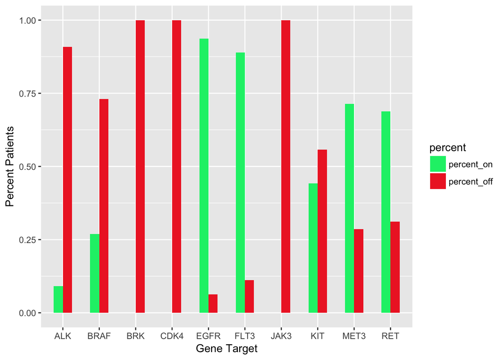

```r
# Of the approved therapies that have a gene target, what count and percent of our GENIE patients
# (that have a "pathogenic" mutation in the same target gene) also have a cancer type to which the
# therapy is approved?
# |gene_target |on_indication |off_indication |total | percent_on| percent_off|
# |:-----------|:-------------|:--------------|:-----|----------:|-----------:|
# |ALK         |1             |10             |11    |      0.091|       0.909|
# |KIT         |23            |29             |52    |      0.442|       0.558|
# |FLT3        |8             |1              |9     |      0.889|       0.111|
# |MET3        |5             |2              |7     |      0.714|       0.286|
# |RET         |22            |10             |32    |      0.688|       0.312|
# |BRAF        |239           |649            |888   |      0.269|       0.731|
# |BRK         |0             |3              |3     |      0.000|       1.000|
# |EGFR        |163           |11             |174   |      0.937|       0.063|
# |CDK4        |0             |4              |4     |      0.000|       1.000|
# |JAK3        |0             |2              |2     |      0.000|       1.000|


# In order to plot the percentages side by side in a barplot, need to melt the data.frame
treated_melt <- melt(treated)
names(treated_melt)[5] <- "percent"
ggplot(treated_melt, aes(x = gene_target, y= value, fill = percent)) +
    geom_bar(stat="identity", width=.5, position = "dodge") +
    xlab("Gene Target") +
    ylab("Percent Patients") +
    scale_fill_manual(values=c("springgreen2", "firebrick2"))
```

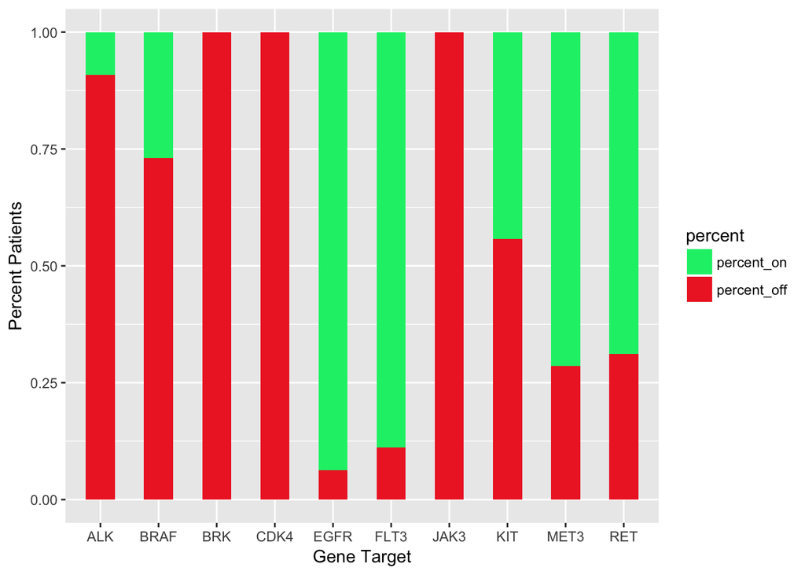

```r
# Stacked rather than dodge
ggplot(treated_melt, aes(x = gene_target, y= value, fill = percent)) +
    geom_bar(stat="identity", width=.5) +
    xlab("Gene Target") +
    ylab("Percent Patients") +
    scale_fill_manual(values=c("springgreen2", "firebrick2"))
```